# Predicción de los datos en Egatur.csv

Sandra de la Fuente

30 de mayo de 2017

```r
#Limpiamos el workspace
rm(list=ls())

setwd("C:/Users/sandr/Desktop/TFM_Master/TFM_DataScience/")

library(dplyr)
```

```r
library(ggplot2)
library(data.table)
library(scales)
library(cluster)
library(NbClust)
```

# 1 Predicción de los datos

En este script se desarrolla el procedimiento para obtener la respuesta a uno de los objetivos de este TFM:

- Segmentación de los turistas según características similares de gasto.

Para ello se utilizará el modelo RFM (Recencia, Frecuencia y Valor Monetario), que consiste en agrupar los registros en distintos clústers o segmentos, de acuerdo a criterios económicos, comportamentales, o de negocio.

La idea es crear distintos segmentos en base a cada una de las 3 variables que hacen al modelo RFM, siguiendo el orden de sus siglas:

- Recencia: Dias transcurridos entre la última visita y el final del periodo analizado.
- Frecuencia: Número de visitas realizadas en dicho periodo.
- Monetización: Gastos turísticos realizadas en este periodo.

El resultado de la triple segmentación dará un grupo ganador que es el que definirá cuáles son los mejores turistas, es decir, “los turistas más propensos a gastar son aquellos que nos han visitado más recientemente, con más frecuencia y gastan más dinero”.

Utilizar este modelo predictivo, consigue mejores resultados para las campañas de marketing por 2 motivos principales:

- Permite dirigirse a cada grupo de turistas con mensajes y ofertas diferentes para optimizar los programas de comunicación para cada segmento y maximizar los resultados económicos de las campañas.
- Conocimiento holístico de los turistas.

Se carga el fichero egaturRFM.csv generado en la etapa anterior “Exploración de los datos”.

```r
egaturDS <- read.table("../data_exploring_03/egaturRFM.csv", header = T, sep = ",",   fileEncoding="utf-8")
str(egaturDS)
```

```
## 'data.frame':    135149 obs. of  6 variables:
##  $ Id          : Factor w/ 124125 levels "0114EVA0000376",..: 114 115 134 136 137 138 139 140 141 142 ...
##  $ Pais        : int  14 14 14 14 4 4 4 4 4 4 ...
##  $ Destino_CCAA: int  13 13 13 9 1 1 1 1 1 1 ...
##  $ Gasto_Total : num  1465 1690 1891 1672 1010 ...
##  $ Mes         : int  1 1 1 1 1 1 1 1 1 1 ...
##  $ Anyo        : int  2017 2017 2017 2017 2017 2017 2017 2017 2017 2017 ...
```

- id del turista.
- pais del turista.
- destino del turista.
- gasto total.
- mes del viaje.
- año del viaje.

Se analiza los primeros registros del dataset para tener una primera impresión del contenido.

```r
head(egaturDS)
```

```
##               Id Pais Destino_CCAA Gasto_Total Mes Anyo
## 1 0115EVA0000106   14           13    1464.609   1 2017
## 2 0115EVA0000142   14           13    1690.454   1 2017
## 3 0115EVA0000872   14           13    1890.817   1 2017
## 4 0115EVA0001326   14            9    1671.538   1 2017
## 5 0115EVA0001394    4            1    1009.927   1 2017
## 6 0115EVA0001395    4            1    1602.032   1 2017
```

Y los últimos para detectar problemas en la carga de los datos, incongruencias con los nombres de los campos y sus contenidos.

```r
tail(egaturDS)
```

```
##                    Id Pais Destino_CCAA Gasto_Total Mes Anyo
## 135144 20151200037718    8           11    304.9839  12 2015
## 135145 20151200037720   11           10    569.7706  12 2015
## 135146 20151200037721    3            7    172.9911  12 2015
## 135147 20151200037722    8            1    994.0879  12 2015
## 135148 20151200037723    3           16    188.8411  12 2015
## 135149 20151200037725    8            1    313.1718  12 2015
```

Obtenemos los estadísticos de las variables para conocer de forma breve, características básicas de los datos con los que se está trabajando.

```r
summary(egaturDS)
```

```
##               Id              Pais         Destino_CCAA
##  20151000001801:     6   Min.   : 1.000   Min.   : 1.00
##  20151000001806:     6   1st Qu.: 3.000   1st Qu.: 4.00
##  20151000003209:     6   Median : 8.000   Median : 9.00
##  20151000004531:     6   Mean   : 6.937   Mean   : 7.64
##  20151000004533:     6   3rd Qu.:10.000   3rd Qu.:10.00
##  20151000004696:     6   Max.   :15.000   Max.   :19.00
##  (Other)       :135113
##   Gasto_Total            Mes              Anyo
##  Min.   :   18.27   Min.   : 1.000   Min.   :2015
##  1st Qu.:  579.18   1st Qu.: 3.000   1st Qu.:2016
##  Median :  881.62   Median : 6.000   Median :2016
##  Mean   : 1124.00   Mean   : 6.453   Mean   :2016
##  3rd Qu.: 1278.39   3rd Qu.:10.000   3rd Qu.:2016
##  Max.   :40585.24   Max.   :12.000   Max.   :2017
##
```

Se crea dos variables nuevas:

- Fecha con la unión del mes y año, como no está informado el día, se define para todas las fechas el día 01.
- Frecuencia para el RFM, inicializada a 1.

Se elimina las variables Mes y Anyo.

```r
egaturDS$Gasto_Total<-as.numeric(egaturDS$Gasto_Total)

egaturDS$Pais<-as.factor(egaturDS$Pais)
egaturDS$Destino_CCAA<-as.factor(egaturDS$Destino_CCAA)

egaturDS$Fecha <- as.Date(paste("01", as.numeric(egaturDS$Mes), as.numeric(egaturDS$Anyo), sep="-"),
                      format = "%d-%m-%Y")


egaturDS$Mes <- NULL
egaturDS$Anyo <- NULL
```

Se crea un nuevo dataset egaturRFM con las variables necesarias para el Modelo RFM.

```r
egaturRFM <- egaturDS[c(1,4,5)]

egaturRFM$Gasto_Total<-as.numeric(egaturRFM$Gasto_Total)
egaturRFM$Frecuencia <-1

str(egaturRFM)
```

```
## 'data.frame':    135149 obs. of  4 variables:
##  $ Id         : Factor w/ 124125 levels "0114EVA0000376",..: 114 115 134 136 137 138 139 140 141 142 ...
##  $ Gasto_Total: num  1465 1690 1891 1672 1010 ...
##  $ Fecha      : Date, format: "2017-01-01" "2017-01-01" ...
##  $ Frecuencia : num  1 1 1 1 1 1 1 1 1 1 ...
```

```r
summary(egaturRFM)
```

```
##               Id          Gasto_Total           Fecha
##  20151000001801:     6   Min.   :   18.27   Min.   :2015-10-01
##  20151000001806:     6   1st Qu.:  579.18   1st Qu.:2016-03-01
##  20151000003209:     6   Median :  881.62   Median :2016-07-01
##  20151000004531:     6   Mean   : 1124.00   Mean   :2016-07-02
##  20151000004533:     6   3rd Qu.: 1278.39   3rd Qu.:2016-11-01
##  20151000004696:     6   Max.   :40585.24   Max.   :2017-04-01
##  (Other)       :135113
##    Frecuencia
##  Min.   :1
##  1st Qu.:1
##  Median :1
##  Mean   :1
##  3rd Qu.:1
##  Max.   :1
##
```

# 2 Construcción del modelo

Construimos un modelo RFM con las variables Recencia, Frecuencia y Monetización según los datos del dataset egaturRFM, la fecha seleccionada para aplicar el modelo es 2017-07-01.

```r
fechaRFM = as.Date("2017-07-01")

RFM_EGATUR=summarise(group_by(egaturRFM, Id),
          RECENCIA = as.numeric(min(fechaRFM-Fecha, na.rm = TRUE)),
          FRECUENCIA = sum(Frecuencia, na.rm = TRUE),
          MONETIZACION =  sum(Gasto_Total, na.rm = TRUE)
)
```

# 3 Realización de gráficas para visualizar la densidad de los turistas

Se realizan las siguientes gráficas para mostrar la densidad de los turistas a través del Modelo RFM.

1. Gráfico de Densidad Modelo RFM_EGATUR$FRECUENCIA - RFM_EGATUR$RECENCIA

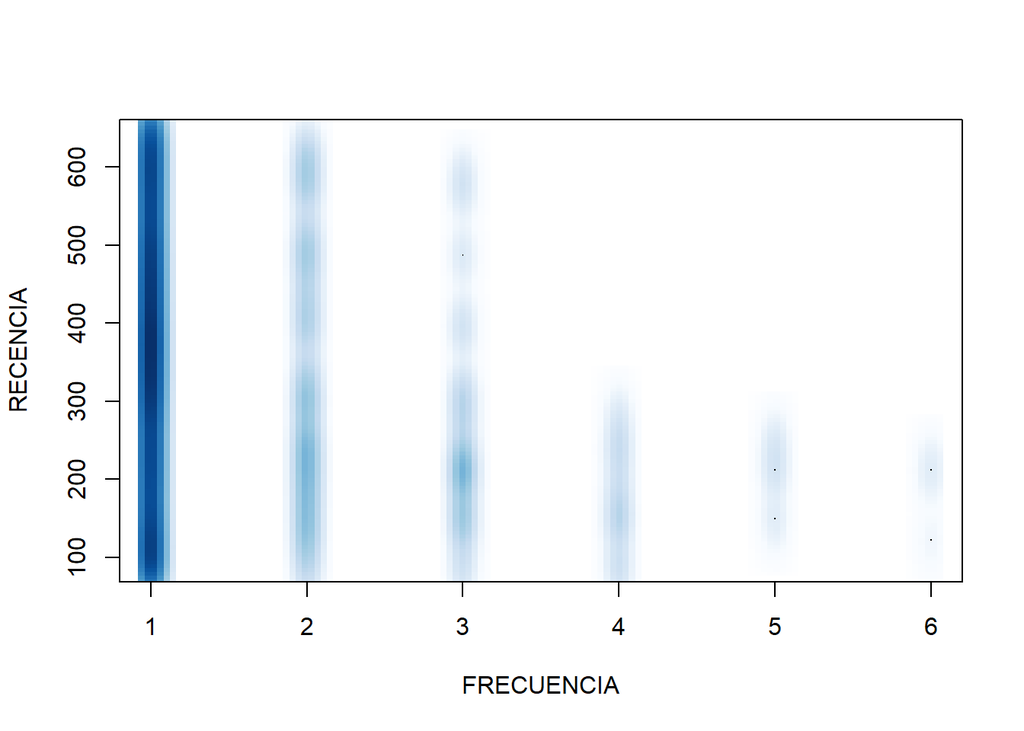

```r
smoothScatter(RFM_EGATUR$FRECUENCIA,RFM_EGATUR$RECENCIA, xlab="FRECUENCIA", ylab="RECENCIA")
```

2. Gráfico de Densidad Modelo RFM_EGATUR$FRECUENCIA - RFM_EGATUR$MONETIZACION

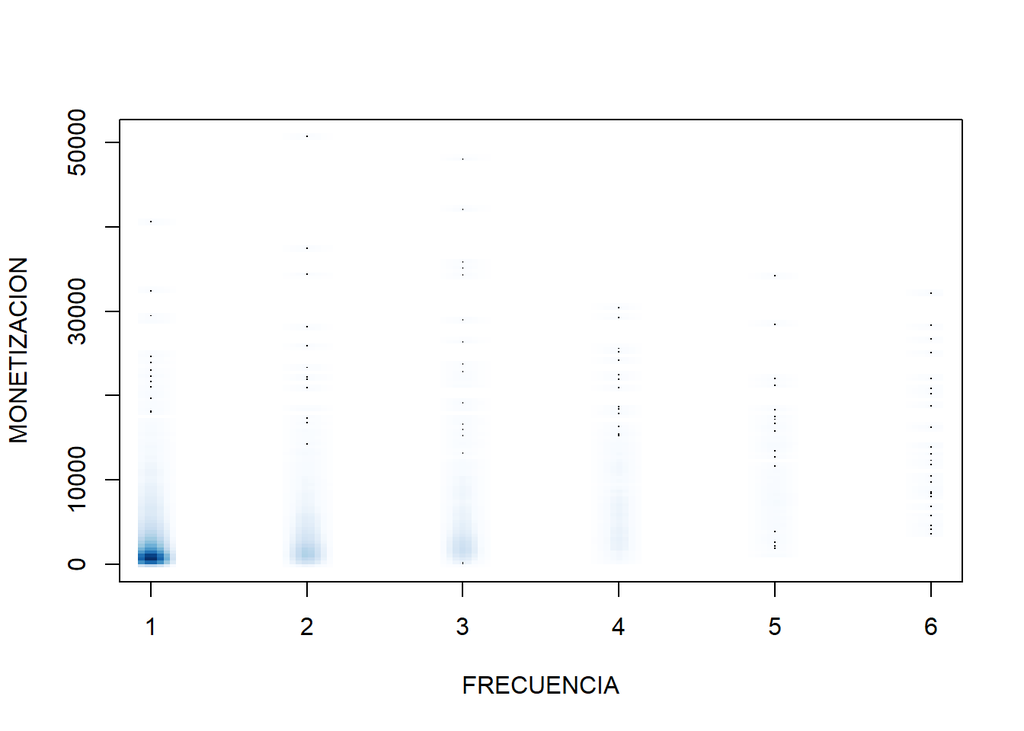

```r
smoothScatter(RFM_EGATUR$FRECUENCIA,RFM_EGATUR$MONETIZACION, xlab="FRECUENCIA", ylab="MONETIZACION")
```

3. Gráfico de Densidad Modelo RFM_EGATUR$RECENCIA - RFM_EGATUR$MONETIZACION

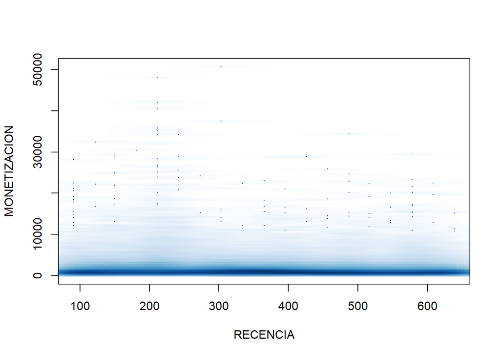

```r
smoothScatter(RFM_EGATUR$RECENCIA,RFM_EGATUR$MONETIZACION, xlab="RECENCIA",ylab="MONETIZACION")
```

# 4 Método Elbow

Uno de los objetivos de este TFM, es clasificar en grupos a los turistas según el gasto realizado, para implementar el cálculo óptimo en la selección del número de Clusters, se ha utilizado el método Elbow (método del codo).

Este método utiliza los valores de la inercia obtenidos tras aplicar el K-means a diferente número de Clusters (desde 1 a N Clusters), siendo la inercia la suma de las distancias al cuadrado de cada objeto del Cluster a su centroide.

Una vez obtenidos los valores de la inercia tras aplicar el K-means de 1 a N Clusters, se representa en una gráfica lineal la inercia respecto del número de Clusters.

En esta gráfica se debería de apreciar un cambio brusco en la evolución de la inercia, teniendo la línea representada una forma similar a la de un brazo y su codo.

El punto en el que se observa ese cambio brusco en la inercia, dirá el número óptimo de Clusters a seleccionar para ese dataset, o dicho de otra manera, el punto que representaría al codo del brazo será el número óptimo de Clusters para ese dataset.

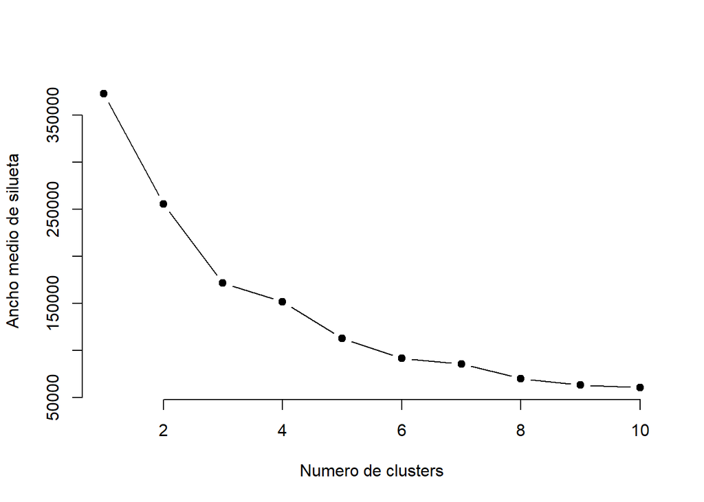

```r
RFM_EGATUR_NORM=scale(RFM_EGATUR[,-1])

mydata <- RFM_EGATUR_NORM
wss <- (nrow(mydata)-1)*sum(apply(mydata,2,var))
for (i in 2:10) wss[i] <- sum(kmeans(mydata,
                                     centers=i)$withinss)




plot(1:10, wss, type = "b", pch = 19, frame = FALSE, xlab = "Numero de clusters", ylab = "Ancho medio de silueta")
```

# 5 Clusters

En este bloque se realiza el cálculo de los segmentos, en función al número de Clusters óptimos seleccionados según el método Elbow del paso anterior.

El modelo a aplicar es K-means, es un método de agrupamiento que tiene como objetivo la partición de un conjunto de n observaciones en k grupos, en el que cada observación pertenece al grupo cuyo valor medio es más cercano.

En este TFM se va a realizar una comparativa entre 3 y 6 clusters.

Bloque de Segmentación mediante Modelo RFM para 3 Clusters:

```r
NUM_CLUSTERS=3
set.seed(1234)

Modelo=kmeans(RFM_EGATUR_NORM,NUM_CLUSTERS)

## SELECCIONAMOS LOS GRUPOS
Segmentos=Modelo$cluster

## MOSTRAMOS LA DISTRIBUCIÓN DE LOS GRUPOS
table(Segmentos)
```

```
## Segmentos
##     1     2     3
## 63004 54017  7104
```

```r
## MOSTRAMOS LOS DATOS REPRESENTATIVOS DE LOS GRUPOS
aggregate(RFM_EGATUR[,-1], by = list(Segmentos), mean)
```

```
##   Group.1 RECENCIA FRECUENCIA MONETIZACION
## 1       1 490.9184   1.009587     1050.121
## 2       2 215.2422   1.005443     1090.094
## 3       3 257.5550   2.425394     3781.201
```

```r
## CENTROS

SEGMENTOS=aggregate(RFM_EGATUR[,-1], by = list(Segmentos), mean)
SEGMENTOS$CONTADOR=table(Segmentos)
NORMALIZACION_MEDIA=apply(RFM_EGATUR[,-1],MARGIN=2,FUN=mean)
NORMALIZACION_SD=apply(RFM_EGATUR[,-1],MARGIN=2,FUN=sd)

## Comprobación de los centroides construidos
Modelo$centers[,1]*NORMALIZACION_SD[1]+NORMALIZACION_MEDIA[1]
```

```
##        1        2        3
## 490.9184 215.2422 257.5550
```

```r
SEGMENTOS$RECENCIA
```

```
## [1] 490.9184 215.2422 257.5550
```

```r
SEGMENTOS
```

```
##   Group.1 RECENCIA FRECUENCIA MONETIZACION CONTADOR
## 1       1 490.9184   1.009587     1050.121    63004
## 2       2 215.2422   1.005443     1090.094    54017
## 3       3 257.5550   2.425394     3781.201     7104
```

Se puede apreciar la representación gráfica de la segmentación en el fichero 1.Grafico_Clustering_Kmeans_3_CLUSTERS.png

```r
png(paste("./1.Grafico_Clustering_Kmeans_",NUM_CLUSTERS,"_CLUSTERS.png",sep=""),width = 1024, height = 880)
par(mfrow=c(2, 2),oma = c(1, 0, 3, 0))
plot(RFM_EGATUR$FRECUENCIA,RFM_EGATUR$RECENCIA,col=Segmentos, xlab="FRECUENCIA", ylab="RECENCIA")
plot(c(0,max(RFM_EGATUR$RECENCIA)),c(0,max(RFM_EGATUR$RECENCIA)), type="n", axes=F, xlab="", ylab="",xlim=c(0,max(RFM_EGATUR$RECENCIA)),ylim=c(0,max(RFM_EGATUR$RECENCIA)))
legend(1,max(RFM_EGATUR$RECENCIA)/2-1,legend=c(1:NUM_CLUSTERS),yjust = 0.5,col=c(1:NUM_CLUSTERS),pch=15,cex=2)
plot(RFM_EGATUR$FRECUENCIA,RFM_EGATUR$MONETIZACION,col=Segmentos, xlab="FRECUENCIA",ylab="MONETIZACION")
plot(RFM_EGATUR$RECENCIA,RFM_EGATUR$MONETIZACION,col=Segmentos, xlab="RECENCIA",ylab="MONETIZACION")
mtext(paste("Clusterización kmeans de clientes mediante Modelo RFM",sep=""), outer = TRUE, cex = 2)
dev.off()
```

Bloque de Segmentación mediante Modelo RFM para 6 Clusters.

```r
NUM_CLUSTERS=6
set.seed(1234)

Modelo=kmeans(RFM_EGATUR_NORM,NUM_CLUSTERS)

## SELECCIONAMOS LOS GRUPOS
Segmentos=Modelo$cluster

## MOSTRAMOS LA DISTRIBUCIÓN DE LOS GRUPOS
table(Segmentos)
```

```
## Segmentos
##     1     2     3     4     5     6
## 38470 41687  3681   730 32992  6565
```

```r
## MOSTRAMOS LOS DATOS REPRESENTATIVOS DE LOS GRUPOS
aggregate(RFM_EGATUR[,-1], by = list(Segmentos), mean)
```

```
##   Group.1 RECENCIA FRECUENCIA MONETIZACION
## 1       1 545.4654   1.000026     905.2979
## 2       2 354.3256   1.000000    1046.4076
## 3       3 362.5675   1.078511    5158.3808
## 4       4 232.5178   3.510959   11491.7999
## 5       5 161.3129   1.000000     993.1429
## 6       6 274.9467   2.355826    2028.3131
```

```r
## CENTROS

SEGMENTOS=aggregate(RFM_EGATUR[,-1], by = list(Segmentos), mean)
SEGMENTOS$CONTADOR=table(Segmentos)
NORMALIZACION_MEDIA=apply(RFM_EGATUR[,-1],MARGIN=2,FUN=mean)
NORMALIZACION_SD=apply(RFM_EGATUR[,-1],MARGIN=2,FUN=sd)

## Comprobación de los centroides construidos
Modelo$centers[,1]*NORMALIZACION_SD[1]+NORMALIZACION_MEDIA[1]
```

```
##        1        2        3        4        5        6
## 545.4654 354.3256 362.5675 232.5178 161.3129 274.9467
```

```r
SEGMENTOS$RECENCIA
```

```
## [1] 545.4654 354.3256 362.5675 232.5178 161.3129 274.9467
```

```r
SEGMENTOS
```

```
##   Group.1 RECENCIA FRECUENCIA MONETIZACION CONTADOR
## 1       1 545.4654   1.000026     905.2979    38470
## 2       2 354.3256   1.000000    1046.4076    41687
## 3       3 362.5675   1.078511    5158.3808     3681
## 4       4 232.5178   3.510959   11491.7999      730
## 5       5 161.3129   1.000000     993.1429    32992
## 6       6 274.9467   2.355826    2028.3131     6565
```

Se puede apreciar la representación gráfica de la segmentación en el fichero 2.Grafico_Clustering_Kmeans_6_CLUSTERS.png

```r
png(paste("./2.Grafico_Clustering_Kmeans_",NUM_CLUSTERS,"_CLUSTERS.png",sep=""),width = 1024, height = 880)
par(mfrow=c(2, 2),oma = c(1, 0, 3, 0))
plot(RFM_EGATUR$FRECUENCIA,RFM_EGATUR$RECENCIA,col=Segmentos, xlab="FRECUENCIA", ylab="RECENCIA")
plot(c(0,max(RFM_EGATUR$RECENCIA)),c(0,max(RFM_EGATUR$RECENCIA)), type="n", axes=F, xlab="", ylab="",xlim=c(0,max(RFM_EGATUR$RECENCIA)),ylim=c(0,max(RFM_EGATUR$RECENCIA)))
legend(1,max(RFM_EGATUR$RECENCIA)/2-1,legend=c(1:NUM_CLUSTERS),yjust = 0.5,col=c(1:NUM_CLUSTERS),pch=15,cex=2)
plot(RFM_EGATUR$FRECUENCIA,RFM_EGATUR$MONETIZACION,col=Segmentos, xlab="FRECUENCIA",ylab="MONETIZACION")
plot(RFM_EGATUR$RECENCIA,RFM_EGATUR$MONETIZACION,col=Segmentos, xlab="RECENCIA",ylab="MONETIZACION")
mtext(paste("Clusterización kmeans de clientes mediante Modelo RFM",sep=""), outer = TRUE, cex = 2)
dev.off()
```

# 6 Conclusiones

El objetivo es hacer una segmentación de los turistas según características de gasto similares, para poder definir acciones de marketing específicas para cada tipo de turista, acciones publicitarias, así como lanzamiento de promociones especiales dirigidas a un turista objetivo.

La idea es crear distintos segmentos en base a cada una de las 3 variables que hacen al modelo RFM, siguiendo el orden de sus siglas:

Recencia: Dias transcurridos entre la última visita y el final del periodo analizado (01-07-2017) Frecuencia: Número de visitas realizadas en dicho periodo. Monetización: suma de los gastos turísticos realizadas en este periodo.

Existen diferencias entre los grupos obtenidos según el número de Clusters, si se quiere realizar un análisis más detallado de cada perfil de turistas se necesita un mayor grado de clusterización.

Por ello se han definido dos estudios en este TFM, 3 y 6 Clusters, seleccionados en los bloques anteriores:

## 6.1 3 Clusters

Existe el grupo 3 definido como los “turistas vips”, son aquellos que han realizan un gasto alto en España, que han visitado España recientemente y con mayor frecuencia.

Los grupos 1 y 2 son los más numerosos, tienen características similares en cuanto al gasto realizado y la frecuencia, pero por el contrario el grupo 1 lleva mas tiempo sin visitar España.

## 6.2 6 Clusters

Del resultado de la segmentación en los 6 clusters, se observa dos grupos (4 y 6) definidos como mejores turistas, es decir, “los turistas más propensos a gastar son aquellos que nos han visitado más recientemente, con más frecuencia y gastan más dinero”, es decir, recencia baja, frecuencia alta y monetización alta, pero por el contrario son los menos numerosos.

En cambio, el grupo 1 es objetivo de campañas de marketing, promociones u ofertas puesto que el gasto es muy bajo, la frecuencia también y ha pasado bastante tiempo sin visitar España.

# 7 Visualización de los datos

En este apartado se procede a analizar los datos generados en un dashboard interactivo, para ello se va a crear un fichero csv con los datos calculados en el modelo, el cluster al que pertenece el turista y el país de procedencia.

Se añade una variable al dataset RFM_EGATUR, con el número de Cluster de cada instancia, el país de origen y el destino CCAA, con el fin de generar un fichero “RFM_EGATUR_CLUSTERS_6.csv” y visualizar los datos en Tableau.

```r
df_Paises <- read.table("../data_cleaning_02/PaisesE.csv", header = T, sep = ";",   fileEncoding="utf-8")
df_Paises
```

```
##    Pais           Nombre
## 1     1         Alemania
## 2     2          Bélgica
## 3     3          Francia
## 4     4          Irlanda
## 5     5           Italia
## 6     6     Países Bajos
## 7     7         Portugal
## 8     8      Reino Unido
## 9     9           Suiza
## 10   10            Rusia
## 11   11  Países Nórdicos
## 12   12  Resto de Europa
## 13   13             EEUU
## 14   14 Resto de América
## 15   15 Resto del mundo
```

```r
df_Paises$Pais<-as.factor(df_Paises$Pais)

df_CCAA <- read.table("../data_cleaning_02/CCAAE.csv", header = T, sep = ";",  fileEncoding="utf-8")
df_CCAA
```

```
##    Codigo                    CCAA
## 1       1               Andalucía
## 2       2                  Aragón
## 3       3 Principado de Asturias
## 4       4               Baleares
## 5       5               Canarias
## 6       6              Cantabria
## 7       7         Castilla y León
## 8       8     Castilla La Mancha
## 9       9                Cataluña
## 10     10         Com.Valenciana
## 11     11           Extremadura
## 12     12               Galicia
## 13     13            Com.Madrid
## 14     14      Región de Murcia
## 15     15            C.F.Navarra
## 16     16             País Vasco
## 17     17               La Rioja
## 18     18                   Ceuta
## 19     19                 Melilla
```

```r
df_CCAA$Codigo<-as.factor(df_CCAA$Codigo)
colnames(df_CCAA)[colnames(df_CCAA)=="Codigo"] <- "Destino_CCAA"

#sustituimos para la visualizacion correcta en Tableau el nombre de las CCAA

df_CCAA$CCAA <- gsub("Com.Madrid ",  "Madrid", df_CCAA$CCAA)
df_CCAA$CCAA <- gsub("Com.Valenciana ",  "Valencia", df_CCAA$CCAA)
df_CCAA$CCAA <- gsub("C.F.Navarra ",  "Navarra", df_CCAA$CCAA)


dfmerge_Pais <- inner_join(egaturDS,df_Paises)
dfmerge_CCCAA <- inner_join(dfmerge_Pais,df_CCAA)
egaturRFM_Aux <- dfmerge_CCCAA[c(1,6,7)]

RFM_EGATUR$CLUSTER <- Modelo$cluster

dfmergeFinal <- inner_join(RFM_EGATUR,egaturRFM_Aux)
colnames(dfmergeFinal)[colnames(dfmergeFinal)=="Nombre"] <- "PAIS"

write.csv(dfmergeFinal, file = "RFM_EGATUR_CLUSTERS_6.csv", row.names=FALSE)
```